# Color of INK WARUNTORN

Ink Waruntorn is one of the most famous singer for the past few years. I am also her fanclub and inspired by her song. In this project, we will explore style, characteristic of song and construct a model generating INK WARUNTORN lyric. As there is no datasource available for us, we are going to collect data from website using web scraping and spotify using Web API.

> :)

[figure not shown]

```python
import os
import requests
import pandas as pd
from tqdm import tqdm
from bs4 import BeautifulSoup
from collections import defaultdict
```

## Data Collection

Datasource we used in this notebook:

- **Lyric Data** collected from https://เพลง.meemodel.com
- **Spotify Data** audio features from Web API

If you're interested in data collection process, you can find the cell below. Or, you can skip and go through exploratory data analysis.

### Web Scraping

First let's start with web scraping, I going to collect all lyrics with web scraping using **requests** and **BeautifulSoup** in python

```python
# set project directory
PROJECT_HOME = '/content/drive/MyDrive/color-of-ink-waruntorn'
```

```python
# Create lyric list from INK WARUNTORN url
# Thanks เพลง.meemodel.com for data

ink_url = 'https://เพลง.meemodel.com/ศิลปิน/อิ้งค์%20วรันธร'
root_url = 'https://เพลง.meemodel.com'

response = requests.get(ink_url, verify = False)
soup = BeautifulSoup(response.text, 'html.parser')

tracks = soup.find_all('tr')
track_metadata = defaultdict(list)

for id, tr in tqdm(enumerate(tracks)):
  metadata = [x.text for x in tr.find_all('td')]
  url = [a.get('href') for a in tr.find_all('a')]

  if len(metadata) > 0 and len(url) > 0:

    track_metadata['track_id'].append(id)
    track_metadata['title'].append(metadata[0])
    track_metadata['artist'].append(metadata[1])
    track_metadata['lyric_url'].append(''.join([root_url, url[0]]))

    lyric_response = requests.get(''.join([root_url, url[0]]), verify = False)
    lyric_html = BeautifulSoup(lyric_response.text, 'html.parser')

    track_metadata['lyric'].append(lyric_html.find('div', {'class': 'lyric'}).text)

ink_lyric = pd.DataFrame(track_metadata).set_index('track_id')
```

[output not shown]

[output cut: 14 more lines]

### Spotify Data APIs

Next, collecting song attribute from Spotify

```python
# Create spotify track id dictionary

track_id ={
    'INK': '5fCFj6M5BQQJ8t2EiExd3Z?si=577c75218c644f70',
    'Snap': '0qDfBvaJe1UzCvE2VGTHOV?si=55570694a3814ce3',
    'กลับก่อนนะ':	'7EtCnq7brD1RU8ldqKWB0I?si=bd658bf297a749a4',
    'เก่งแต่เรื่องคนอื่น':	'0N5DeGdC258DI3DZEn2SEI?si=a58a3fabb0c64c8d',
    'เกี่ยวกันไหม':	'5PoQpjsj902TmAtCOKVO2A?si=3a144177aff64d37',
    'ความลับมีในโลก':	'12OcSYq9homFUUyerFDGy2?si=4f3c1b3054ff4c80',
    'ฉันต้องคิดถึงเธอแบบไหน (Cloudy)':	'11APF4YlwtMOLnZFtzlT5I?si=017fbead8a954ca9',
    'ดีใจด้วยนะ':	'4A0mBhjXoX5xa70BtMBJUp?si=6757ddc9ddf64584',
    'เผลอหรือตั้งใจ':	'7GfFmnGewokTR7RwkMpbW5?si=4efedc4acc614090',
    'ไม่อยากเหงาแล้ว':	'1HKi1aNVZYF3u1Way1Gbw8?si=714afee8ba014ea8',
    'ยังรู้สึก':	'2MQlQVep8jvfLzvTp6g66G?si=f7e83676003d4f25',
    'รอหรือพอ':	'5m4KRqfXUks7t2gPJrz2Z6?si=eefbce63034c4a92',
    'ลบไม่ได้ช่วยให้ลืม':	'1DmSuLOeFWm23RqLhiRLdr?si=4945151949414254',
    'โลกที่ไม่มีเธอ':	'4DvQkReb1e05aruQUOygs4?si=819518ffd57448fa',
    'สายตาหลอกกันไม่ได้':	'7Mcy886fsW8eUQzIwdLnVC?si=9e0d679338c54010',
    'เหงา เหงา (Insomnia)':	'7vkpeMzZAqCNHKuhajD62l?si=b5c2e1b009b54ea0',
    'อยากเริ่มต้นใหม่กับคนเดิม':	'0g6sPkauqoHKPtLzYGc1z6?si=1c9e280c28094b5c'
  }

ink_lyric['spotify_track_id'] = ink_lyric['title'].apply(lambda title: track_id.get(title))
ink_lyric.head()
```

| track_id | title | artist | lyric_url | lyric | spotify_track_id |
| --- | --- | --- | --- | --- | --- |
| 1 | INK | อิ้งค์ วรันธร | https://เพลง.meemodel.com/เนื้อเพลง/INK_อิ้งค์... | \nระหว่างที่ฉันและเธอ\r\nอยู่ด้วยกันกลางเสียงเ... | 5fCFj6M5BQQJ8t2EiExd3Z?si=577c75218c644f70 |
| 2 | Snap | อิ้งค์ วรันธร | https://เพลง.meemodel.com/เนื้อเพลง/Snap_อิ้งค... | \nทุก ๆ ครั้งที่เห็นดาวบนฟ้าทุก ๆ ครั้งฉันนั้น... | 0qDfBvaJe1UzCvE2VGTHOV?si=55570694a3814ce3 |
| 3 | กลับก่อนนะ | อิ้งค์ วรันธร | https://เพลง.meemodel.com/เนื้อเพลง/กลับก่อนนะ... | \nที่ฉันยอมมาในคืนนี้ รู้ไหมว่าเพราะอะไร\r\nไม... | 7EtCnq7brD1RU8ldqKWB0I?si=bd658bf297a749a4 |
| 4 | เก่งแต่เรื่องคนอื่น | อิ้งค์ วรันธร | https://เพลง.meemodel.com/เนื้อเพลง/เก่งแต่เรื... | \nใครจะมาปรึกษาให้ฉันแก้ปัญหา\r\nจะไปยากอะไร อ... | 0N5DeGdC258DI3DZEn2SEI?si=a58a3fabb0c64c8d |
| 5 | เกี่ยวกันไหม | อิ้งค์ วรันธร | https://เพลง.meemodel.com/เนื้อเพลง/เกี่ยวกันไ... | \nทำไม เพลงรักเพลงซึ้งที่ฉันไม่เคยชอบฟัง\r\nพอ... | 5PoQpjsj902TmAtCOKVO2A?si=3a144177aff64d37 |

```python
ink_lyric.to_csv(
    os.path.join(PROJECT_HOME, 'data', 'ink_lyrics.csv'), index = False, encoding = 'utf-8'
)
```

```python
CLIENT_ID = '76d353dfd04447e2b0584274f12b526f'
CLIENT_SECRET = '2b992ccc653341dd904ece8a2bbfefc4'
REDIRECT_URI = 'http://localhost'

AUTH_URL = 'https://accounts.spotify.com/api/token'

# POST
auth_response = requests.post(AUTH_URL, {
    'grant_type': 'client_credentials',
    'client_id': CLIENT_ID,
    'client_secret': CLIENT_SECRET,
})

# convert the response to JSON
auth_response_data = auth_response.json()

# save the access token
access_token = auth_response_data['access_token']

headers = {
    'Authorization': 'Bearer {token}'.format(token=access_token)
}

# base URL of all Spotify API endpoints
BASE_URL = 'https://api.spotify.com/v1/'

# Track ID from the URI
track_id = '6y0igZArWVi6Iz0rj35c1Y'

# actual GET request with proper header
r = requests.get(BASE_URL + 'audio-features/' + track_id, headers=headers)
```

```python
requests.get(
          BASE_URL + 'audio-features/' + '5fCFj6M5BQQJ8t2EiExd3Z',
          headers = headers
        ).json()
```

```
{'acousticness': 0.0336,
 'analysis_url': 'https://api.spotify.com/v1/audio-analysis/5fCFj6M5BQQJ8t2EiExd3Z',
 'danceability': 0.693,
 'duration_ms': 160000,
 'energy': 0.691,
 'id': '5fCFj6M5BQQJ8t2EiExd3Z',
 'instrumentalness': 2.11e-05,
 'key': 5,
 'liveness': 0.194,
 'loudness': -6.456,
 'mode': 1,
 'speechiness': 0.0528,
 'tempo': 119.955,
 'time_signature': 4,
 'track_href': 'https://api.spotify.com/v1/tracks/5fCFj6M5BQQJ8t2EiExd3Z',
 'type': 'audio_features',
 'uri': 'spotify:track:5fCFj6M5BQQJ8t2EiExd3Z',
 'valence': 0.597}
```

```python
# base URL of all Spotify API endpoints
BASE_URL = 'https://api.spotify.com/v1/'
# Track ID from the URI
track_id = '5fCFj6M5BQQJ8t2EiExd3Z'

# actual GET request with proper header
audio_features = []

for _, row in ink_lyric.iterrows():
  if row['spotify_track_id'] is not None:
    r = requests.get(
          BASE_URL + 'audio-features/' + row['spotify_track_id'],
          headers = headers
        )
    audio_features.append(r.json())
```

```python
ink_audio_features = pd.DataFrame(audio_features)
ink_audio_features.to_csv(
    os.path.join(PROJECT_HOME, 'data', 'ink_audio_features.csv'),
    index = False
)
```

### Dependencies installation

```python
# @title
!pip install pythainlp
!wget -q https://github.com/Phonbopit/sarabun-webfont/raw/master/fonts/thsarabunnew-webfont.ttf
```

## Exploratory Data Analysis

```python
import re
import numpy as np
import pandas as pd
import seaborn as sns
import matplotlib
import matplotlib.pyplot as plt
from wordcloud import WordCloud
from pythainlp.corpus import thai_stopwords
from pythainlp import sent_tokenize, word_tokenize
```

```python
# @title

ink_lyric.head()
```

| track_id | title | artist | lyric_url | lyric | spotify_track_id |
| --- | --- | --- | --- | --- | --- |
| 1 | INK | อิ้งค์ วรันธร | https://เพลง.meemodel.com/เนื้อเพลง/INK_อิ้งค์... | \nระหว่างที่ฉันและเธอ\r\nอยู่ด้วยกันกลางเสียงเ... | 5fCFj6M5BQQJ8t2EiExd3Z?si=577c75218c644f70 |
| 2 | Snap | อิ้งค์ วรันธร | https://เพลง.meemodel.com/เนื้อเพลง/Snap_อิ้งค... | \nทุก ๆ ครั้งที่เห็นดาวบนฟ้าทุก ๆ ครั้งฉันนั้น... | 0qDfBvaJe1UzCvE2VGTHOV?si=55570694a3814ce3 |
| 3 | กลับก่อนนะ | อิ้งค์ วรันธร | https://เพลง.meemodel.com/เนื้อเพลง/กลับก่อนนะ... | \nที่ฉันยอมมาในคืนนี้ รู้ไหมว่าเพราะอะไร\r\nไม... | 7EtCnq7brD1RU8ldqKWB0I?si=bd658bf297a749a4 |
| 4 | เก่งแต่เรื่องคนอื่น | อิ้งค์ วรันธร | https://เพลง.meemodel.com/เนื้อเพลง/เก่งแต่เรื... | \nใครจะมาปรึกษาให้ฉันแก้ปัญหา\r\nจะไปยากอะไร อ... | 0N5DeGdC258DI3DZEn2SEI?si=a58a3fabb0c64c8d |
| 5 | เกี่ยวกันไหม | อิ้งค์ วรันธร | https://เพลง.meemodel.com/เนื้อเพลง/เกี่ยวกันไ... | \nทำไม เพลงรักเพลงซึ้งที่ฉันไม่เคยชอบฟัง\r\nพอ... | 5PoQpjsj902TmAtCOKVO2A?si=3a144177aff64d37 |

```python
# @title

ink_corpus = re.sub('[\r]', '', ' '.join(ink_lyric['lyric']))
print(ink_corpus[:500])
```

```
ระหว่างที่ฉันและเธอ
อยู่ด้วยกันกลางเสียงเพลง
ได้มายืนใกล้ๆ กัน
ฉันมีเรื่องจะถามเธอ

ชั่วโมงนี้เป็นไปได้ไหม ขอให้เธอทิ้งทุกอย่างไว้ก่อน
ชั่วโมงนี้ช่างมันไปไม่ต้องสนใจ
ขอแค่เราได้ไหม แค่ฉันกับเธอ
แค่ฉันกับเธอ
แค่ฉันกับเธอ
แค่ฉันกับเธอ

เพราะคืนนี้ มันจะไม่เหมือนค่ำคืนไหนที่เจอ
ถ้าเราไม่ได้อยู่ด้วยกัน
มันก็คงจะน่าเสียดาย
อยากจะขอเธอ

ชั่วโมงนี้เป็นไปได้ไหม ขอให้เธอทิ้งทุกอย่างไว้ก่อน
ชั่วโมงนี้ช่างมันไปไม่ต้องสนใจ
ขอแค่เราได้ไหม แค่ฉันกับเธอ
แค่ฉันกับเธอ
แค่ฉันกับเธอ
แค่ฉันกับเธอ
ทุก ๆ ครั้งที่เห
```

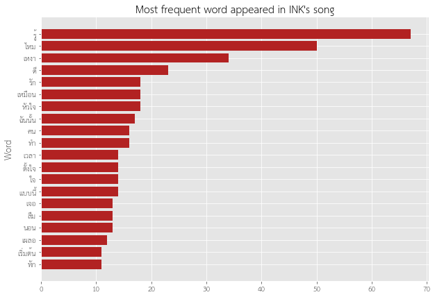

```python
# -*- coding: utf-8 -*-

from collections import Counter, defaultdict

word_freq = []

stop_words = list(thai_stopwords())
tokenized_corpus = [word for word in word_tokenize(ink_corpus) if word not in stop_words + ['(', ')', '**']]

tokenized_corpus = ' '.join(tokenized_corpus)
#tokenized_corpus = re.sub(r'[^\w]', '', tokenized_corpus)

for w, f in dict(Counter(tokenized_corpus.split(' '))).items():
#for w, f in dict(Counter(word_tokenize(ink_corpus))).items():
  word_freq.append({'word': w, 'freq': f})

word_data = pd.DataFrame(word_freq).sort_values(by = 'freq', ascending = True)
word_data = word_data[~word_data['word'].isin(['', '\n'])]
top_20_word_data = word_data.tail(20)

matplotlib.font_manager.fontManager.addfont('thsarabunnew-webfont.ttf')
matplotlib.rc('font', family = 'TH Sarabun New')

plt.style.use('ggplot')
plt.figure(figsize = (10, 7))

plt.barh(
    top_20_word_data['word'],
    top_20_word_data['freq'],
    color = 'firebrick'
)
plt.title("Most frequent word appeared in INK's song")
plt.ylabel('Word')
```

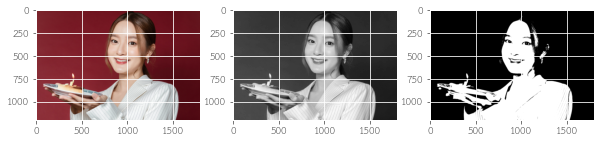

```python
# @title

from PIL import Image
from wordcloud import WordCloud, ImageColorGenerator

img_path = '/content/drive/MyDrive/color-of-ink-waruntorn/data/image/Type-C_Default-Thumbnail_6x4.jpg'
ink_mask = np.array(Image.open(img_path).convert('L'))
#plt.imshow(ink_mask, cmap = 'gray')

def transform_format(val):
  white = 255 - val
  black = val - 0

  if white < black:
    return 255
  else:
    return 0

transformed_mask = np.ndarray((ink_mask.shape[0], ink_mask.shape[1]))

for i in range(len(ink_mask)):
  transformed_mask[i] = list(map(transform_format, ink_mask[i]))

fig, ax = plt.subplots(ncols = 3, figsize = (10, 20))

ax[0].imshow(np.array(Image.open(img_path)))
ax[1].imshow(ink_mask, cmap = 'gray')
ax[2].imshow(transformed_mask, cmap = 'gray')
```

[output not shown]

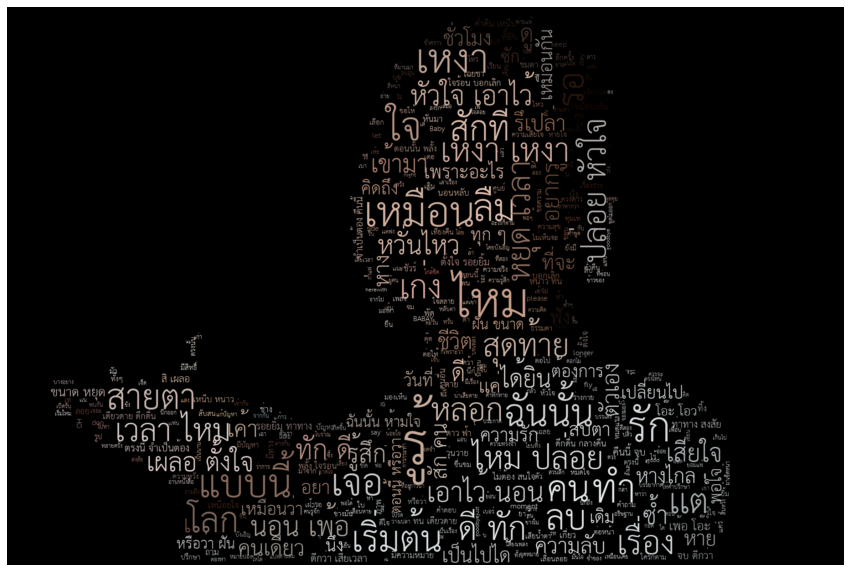

```python
from PIL import Image
from wordcloud import WordCloud, ImageColorGenerator

#mask = np.array(Image.open('/content/drive/MyDrive/color-of-ink-waruntorn/data/77305.png'))

img_path = '/content/drive/MyDrive/color-of-ink-waruntorn/data/image/White-bg.jpg'
ink_mask = np.array(Image.open(img_path))

# Generate Word Cloud
wordcloud = WordCloud(
              font_path = 'thsarabunnew-webfont.ttf',
              relative_scaling = 0.3,
              scale = 3,
              regexp = r"[ก-๙a-zA-Z']+",
              background_color = "black",
              mask = ink_mask,
              max_font_size = 40,
              margin = 1,
              max_words = 2000
              #contour_width = 0.5,
              #contour_color = 'white'
            )\
            .generate(tokenized_corpus)

image_colors = ImageColorGenerator(ink_mask)

# Store to file
#wordcloud.to_file('/content/drive/MyDrive/color-of-ink-waruntorn/data/77305.png')

#fig, axes = plt.subplots(ncols = 2, figsize = (15, 15))

plt.figure(figsize = (15, 15))
plt.imshow(wordcloud.recolor(color_func = image_colors), interpolation = 'bilinear')
plt.axis('off')
```

```python
# @title

ink_audio_features['duration_min'] = ink_audio_features['duration_ms'].apply(lambda t: t / (60000))
ink_audio_features.head()
```

|  | danceability | energy | key | loudness | mode | speechiness | acousticness | instrumentalness | liveness | valence | tempo | type | id | uri | track_href | analysis_url | duration_ms | time_signature | duration_min |
| --- | --- | --- | --- | --- | --- | --- | --- | --- | --- | --- | --- | --- | --- | --- | --- | --- | --- | --- | --- |
| 0 | 0.693 | 0.691 | 5 | -6.456 | 1 | 0.0528 | 0.033600 | 0.000021 | 0.1940 | 0.597 | 119.955 | audio_features | 5fCFj6M5BQQJ8t2EiExd3Z | spotify:track:5fCFj6M5BQQJ8t2EiExd3Z | https://api.spotify.com/v1/tracks/5fCFj6M5BQQJ... | https://api.spotify.com/v1/audio-analysis/5fCF... | 160000 | 4 | 2.666667 |
| 1 | 0.678 | 0.792 | 0 | -4.715 | 1 | 0.0268 | 0.000525 | 0.003210 | 0.0878 | 0.583 | 120.003 | audio_features | 0qDfBvaJe1UzCvE2VGTHOV | spotify:track:0qDfBvaJe1UzCvE2VGTHOV | https://api.spotify.com/v1/tracks/0qDfBvaJe1Uz... | https://api.spotify.com/v1/audio-analysis/0qDf... | 238500 | 4 | 3.975000 |
| 2 | 0.613 | 0.598 | 5 | -5.321 | 1 | 0.0269 | 0.161000 | 0.000000 | 0.1110 | 0.270 | 89.983 | audio_features | 7EtCnq7brD1RU8ldqKWB0I | spotify:track:7EtCnq7brD1RU8ldqKWB0I | https://api.spotify.com/v1/tracks/7EtCnq7brD1R... | https://api.spotify.com/v1/audio-analysis/7EtC... | 240500 | 4 | 4.008333 |
| 3 | 0.798 | 0.736 | 9 | -5.092 | 1 | 0.0711 | 0.160000 | 0.000019 | 0.0991 | 0.885 | 146.064 | audio_features | 0N5DeGdC258DI3DZEn2SEI | spotify:track:0N5DeGdC258DI3DZEn2SEI | https://api.spotify.com/v1/tracks/0N5DeGdC258D... | https://api.spotify.com/v1/audio-analysis/0N5D... | 186500 | 4 | 3.108333 |
| 4 | 0.653 | 0.642 | 7 | -7.842 | 0 | 0.0389 | 0.183000 | 0.000021 | 0.1820 | 0.725 | 120.022 | audio_features | 5PoQpjsj902TmAtCOKVO2A | spotify:track:5PoQpjsj902TmAtCOKVO2A | https://api.spotify.com/v1/tracks/5PoQpjsj902T... | https://api.spotify.com/v1/audio-analysis/5PoQ... | 253067 | 4 | 4.217783 |

```python
ink_audio_features['duration_min'].describe()
```

```
count    17.000000
mean      3.914236
std       0.602890
min       2.666667
25%       3.741667
50%       3.983333
75%       4.347867
max       4.869467
Name: duration_min, dtype: float64
```

## INK Lyric Generation

In this section, we're going to construct model to compose the song in INK's style :)

```python
import string
import numpy as np
import tensorflow as tf
from tensorflow.keras.preprocessing.text import Tokenizer
from tensorflow.keras.preprocessing.sequence import pad_sequences
from pythainlp import word_tokenize
```

First, we will treat a line as one input sequence. However, I observed some data I collected and found that there's no line break, so I need to manually add \n to each song phrase.

```python
# Add new line \n to track 2 and 17
# display(ink_lyric.loc[17, 'lyric'])
# There is a problem on lyric of track_id 2 and 17
# Fixed by manually add line break

snap_lyric = \
'''
ทุก ๆ ครั้งที่เห็นดาวบนฟ้า\nทุก ๆ ครั้งฉันนั้นก็ไม่เคยห้ามใจ\nอยากเอื้อมไปคว้ามา\nทั้งทั้งที่รู้ว่าชื่นชมได้แค่เพียงสายตา\n
ทุก ๆ ครั้งที่ฉันมองที่เธอ\nทุก ๆ ครั้งฉันนั้นก็ไม่เคยห้ามใจ\nบอกเธอด้วยสายตา\nทั้ง ๆ ที่รู้คงไม่ทำเธอให้มองหันมา\n
แต่ตอนนี้\nใกล้แค่นี้\nหรือว่าฉันฝันไป\nใกล้กันขนาดนี้\nอยากหยุดเวลาไว้จะได้ไหม\nปล่อยให้หัวใจ\nได้ใกล้ใกล้เธอ\nจะเก็บเธอเอาไว้\n
ใช้นอนเพ้อ\nแค่เป็นเธอ แค่เป็นเธอ โอ๊ะโอว \nแค่นี้ก็คงพอ\nรู้ทั้งรู้ว่าฉันยังห่างไกล\nรู้ทั้งรู้ว่าเกินที่จะเป็นไปได้\nแต่แค่สบสายตา\n
อะไรอะไรมันก็พาใจฉันลอยหายไป\nแต่ตอนนี้\nใกล้แค่นี้\nหรือว่าฉันฝันไป\nใกล้กันขนาดนี้\nอยากหยุดเวลาไว้\nจะได้ไหม\n
ปล่อยให้หัวใจได้ใกล้ใกล้เธอ\nจะเก็บเธอเอาไว้\nใช้นอนเพ้อ\nแค่เป็นเธอ แค่เป็นเธอ โอ๊ะโอว \nแค่นี้ก็คงพอ\nอยากหยุดเวลาไว้\n
จะได้ไหม\nปล่อยให้หัวใจ\nได้ใกล้ใกล้เธอ\nจะเก็บเธอเอาไว้\nใช้นอนเพ้อ\nแค่เป็นเธอ แค่เป็นเธอ โอ๊ะโอว \nอยากหยุดเวลาไว้\n
จะได้ไหม\nปล่อยให้หัวใจ\nได้ใกล้ใกล้เธอ\nจะเก็บเธอเอาไว้\nใช้นอนเพ้อ\nแค่เป็นเธอ แค่เป็นเธอ โอ๊ะโอว \nแค่นี้ก็คงพอ\n
Can I stay any longer to keep you herewith me by my side?\nBaby please don't you ever say goodbyejust let this moment fly
'''

insomnia_lyric = '''
แสงดวงดาวที่ดูอบอุ่น ทำไมยิ่งมองยิ่งหนาว\nเสียงบรรเลงบทเพลงเก่า ๆ ยิ่งฟังยิ่งคิดถึงใคร\nสายลมพัดปลิวมาเบา ๆ พาใจลอยไปถึงไหน\n
ผู้คนรอบตัวมีมากมาย ทำไมยิ่งเจอยิ่งเหงา\nไม่อยากรู้แล้วว่าเพราะอะไร \nที่ทำให้เป็นแบบนี้\nแต่ที่อยากจะรู้คงมีแค่เพียง\n
ที่เราห่างกันอย่างนี้ไม่รู้ว่าเธอนั้นรู้สึกอย่างไร\nเหงาเหมือนฉันบ้างไหม\nค่ำคืนเหน็บหนาวฉันยังต้องทนเดียวดาย\n
ส่วนเธอเองนั้นเป็นอย่างไร\nดึกดื่นกลางคืนแบบนี้ ไม่รู้ว่าเธอจะนอนหลับได้ไหม\nเหงาเหมือนกันบ้างไหม\nข่มตานอนแล้ว หัวใจก็ยังวุ่นวาย\n
จะเป็นแบบนี้ไปอีกนานเท่าไหร่ ไม่อยากอยู่แบบเหงา ๆ\nเพื่อนที่เธอเจอะเจอ \nเคยถามถึงฉันบ้างไหม\nเมื่อไปที่ที่เราเคยไป \n
จะมองหากันหรือเปล่า\nไปได้ยินเพลงที่เราเคยฟัง \nเธอเองจะนึกถึงใคร\nรูปคู่ครั้งที่เราเคยถ่าย \nเธอเคยเปิดดูบ้างไหม\nไม่อยากรู้แล้วว่าเพราะอะไร \n
ที่ทำให้เป็นแบบนี้\nแต่ที่อยากจะรู้คงมีแค่เพียง\nที่เราห่างกันอย่างนี้ไม่รู้ว่าเธอนั้นรู้สึกอย่างไร\n
เหงาเหมือนฉันบ้างไหม\nค่ำคืนเหน็บหนาวฉันยังต้องทนเดียวดาย\nส่วนเธอเองนั้นเป็นอย่างไร\nดึกดื่นกลางคืนแบบนี้ \nไม่รู้ว่าเธอจะนอนหลับได้ไหม\n
เหงาเหมือนกันบ้างไหม\nข่มตานอนแล้ว หัวใจก็ยังวุ่นวาย\nจะเป็นแบบนี้ไปอีกนานเท่าไหร่\n
ไม่อยากอยู่แบบเหงา ๆ\n
ที่เราห่างกันอย่างนี้ไม่รู้ว่าเธอนั้นรู้สึกอย่างไร\nเหงาเหมือนฉันบ้างไหม\nค่ำคืนเหน็บหนาวฉันยังต้องทนเดียวดาย\n
ส่วนเธอเองนั้นเป็นอย่างไร\nดึกดื่นกลางคืนแบบนี้ ไม่รู้ว่าเธอจะนอนหลับได้ไหม\nเหงาเหมือนกันบ้างไหม\n
ข่มตานอนแล้ว หัวใจก็ยังวุ่นวาย\nจะเป็นแบบนี้ไปอีกนานเท่าไหร่ \nไม่อยากอยู่แบบเหงา ๆ
'''

ink_lyric.loc[2:, 'lyric'] = snap_lyric
ink_lyric.loc[17, 'lyric'] = insomnia_lyric
```

After we preprocessed all texts, we're going to tokenize. However, Thai language could not be tokenized like english with TensorFlow. We have to tokenize using pythainlp and create word index with TensorFlow.

```python
corpus = '\n'.join(ink_lyric['lyric'])
corpus = corpus.split('\n')
corpus = [re.sub('\r', '', s) for s in corpus if s not in ['', '\r']]

vocab_list = []

for token in corpus:
  token_list = word_tokenize(token)
  token_list = [re.sub(r'\s+', '', token) for token in token_list]
  #print(token_list)
  vocab_list += token_list

OOV_TOKEN = '<OOV>'

vocab_text = ' '.join(vocab_list)
tokenizer = Tokenizer(oov_token = OOV_TOKEN)
tokenizer.fit_on_texts([vocab_text])
```

Next, we convert token list to sequences

```python
word_index = tokenizer.word_index
word_index[' '] = max(word_index.values()) + 1
word_index['?'] = max(word_index.values()) + 1
sequences = []

for token in corpus:
  token_list = word_tokenize(token)
  token_list = [re.sub(r'\s+', '', token.lower()) for token in token_list]
  token_list = [token for token in token_list if token != '']
  seq = []

  for word in token_list:
    seq.append(word_index.get(word))

  sequences.append(seq)
```

Generate input sequences and add padding

```python
# Generate input sequences
input_sequences = []
total_words = len(word_index) + 1
max_length = max([len(token) for token in sequences])

for seq in sequences:
  for i in range(len(seq)):
    input_sequences.append(seq[: i + 1])

padded_sequences = pad_sequences(input_sequences, padding = 'pre', maxlen = max_length)

xs = np.array(padded_sequences[:, :-1])

labels = np.array(padded_sequences[:, -1])
labels = tf.keras.utils.to_categorical(labels, num_classes = total_words)
```

```python
print(f'training shape: {xs.shape}')
print(f'labels shape: {labels.shape}')
```

```
training shape: (4891, 13)
labels shape: (4891, 198)
```

```python
def texts_to_sequences(word_index, token_list):
  sequences = []

  for word in token_list:
    index = word_index.get(re.sub(r'\s+', '', word))
    if index is None:
      print(word)
    sequences.append(index)

  return sequences

test_token = word_tokenize('ทุก ๆ ครั้งที่เห็นดาวบนฟ้า')
print(test_token)
texts_to_sequences(word_index, test_token)
```

```
['ทุก ๆ', ' ', 'ครั้ง', 'ที่', 'เห็น', 'ดาว', 'บน', 'ฟ้า']
```

```
[21, None, 20, 31, 56, 57, 58, 59]
```

```python
model = tf.keras.Sequential([
      tf.keras.layers.Embedding(total_words, 64, input_length = max_length - 1),
      tf.keras.layers.Bidirectional(tf.keras.layers.LSTM(20, return_sequences = True)),
      tf.keras.layers.Bidirectional(tf.keras.layers.LSTM(10)),
      tf.keras.layers.Dense(total_words, activation = 'softmax')
])

model.compile(optimizer = 'adam', loss = 'categorical_crossentropy', metrics = ['accuracy'])

history = model.fit(xs, labels, epochs = 500)
```

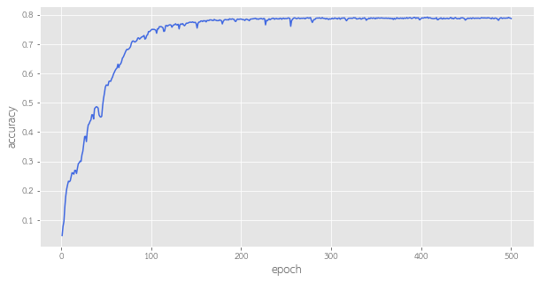

```python
plt.figure(figsize = (10, 5))

plt.plot(range(1, 501), history.history['accuracy'], color = 'royalblue')
plt.xlabel('epoch')
plt.ylabel('accuracy')
```

### Generating prediction

- We will start with eleven word text seed

```python
seed = 'อย่าเพิ่งกลับ ฉันขอร้อง ถ้าเธอจะไป'
#seed = 'กลับก่อนนะ'
next_word = 100

for _ in range(next_word):
  token_list = word_tokenize(seed)
  sequences = [word_index.get(word, 1) for word in token_list]

  sequences = [seq if seq != 1 else np.random.choice(list(word_index.values())) for seq in sequences]

  input_sequences = pad_sequences([sequences], padding = 'pre', maxlen = max_length - 1)

  prediction = model.predict(input_sequences)

  if np.argmax(prediction) != 0:
   rand_id = np.random.choice([1, 2, 3])
   idx = np.sort(prediction)[0][-rand_id]

   word = tokenizer.index_word.get(np.argmax(prediction), "")
   #seed = seed + " " + word
   seed += " " + word

seed = [word for word in seed.split(' ') if word != '']
```

The lyric generated from our model seems gibberish but it's good starting point!!! Hope you enjoy my notebook :)

```python
text = ""

for i, word in enumerate(seed, start = 1):
  if re.search(r'[a-zA-Z]', word):
    text = text + " " + word
  else:
    text = text + word
  if i % 10 == 0:
    text = text + "\n"

print(text)
```

```
อย่าเพิ่งกลับฉันขอร้องถ้าเธอจะไปเหงาสนใจเท่าไหร่คงถึงเพียงเอาไว้
หายทั้งที่ชื่นชมเพียงสายตา sayเธออีกนั้นรู้สึก
นั้นรู้สึกนั้นสนใจ'ให้บ้างหรือเปล่ากับทั้ง
ที่จะสบรู้สึก sayที่ keepบ้างโอวเธอเพราะอะไร
เป็นไปได้โอวเธออีกนั้นรู้สึกนั้นทั้งชื่นชมทั้ง
คืนนี้สายตาไหนโอวเธอขอให้คงคิดถึงได้ยินบ้าง
โอวกับทั้งเกินถึง iคืนนี้ toคืนนี้ถึง
ไหนหรือเปล่าเธอนั้นรู้สึกนั้นทั้งอยากบ้างไหม
เจอไหมทุกอย่างไว้จะอีกหายเธอแล้วทั้ง
ชื่นชมทั้งกับชื่นชมเพียงสายตาหายไปคิดถึงเอาไว้
ขอให้สายตาเธอ
```